# Does daily physical activity affect sleep patterns?

Author: Jake Turicchi

## Background

A bidirectionality in the relationship between sleep and physical activity (PA) is reported, such that reduced sleep can function to reduce physical activity, and reduced physical activity may decrease sleep. It may be that these occur immediately (within a day), or that there is a time lag seperating (for example) increased PA with increased sleep.

Some evidence of a U-shaped (non-linear) effect between PA and sleep has been reported, such that at high amounts of PA (such as in athletes), sleep may reduce. Exercise intensity may also affect these relationships.

Set initial chunk global options

### Set up

Load data and do some initial sorting

```r
#set directory
#setwd('~/Library/Mobile Documents/com~apple~CloudDocs/PhD/NoHoW Analyses/Extra_NH_Analyses/PA and Sleep')
setwd('C:/Users/jaket/iCloudDrive/PhD/NoHoW Analyses/Extra_NH_Analyses/PA and Sleep')


#load PA data (~/Doc..)
PA_files = file_names <- list.files(
  "C:/Users/jaket/iCloudDrive/Documents/GitHub/clustering-of-time-series-pa-data/hrrdailydata",
  pattern = "*.csv", full.names = T)

PA <- rbindlist(lapply(PA_files,fread))

colnames(PA)[1:2]<-c('ip', 'date') #shorten identifier, name date

#load sleep data

sleep <- read.csv('C:/Users/jaket/iCloudDrive/EB_app/EB-App/Predicting weight relapse/Data Streams/GH_sleep_data.csv')

colnames(sleep)[1]<-'ip' #shorten identifier

#load some characteristics data (age, gender, BMI etc)
#/Users/jakw/Documents/merged_test_2020-01-22/R_format/merged_nohow_dataset.RDS
characteristics <- readRDS("C:/Users/jaket/iCloudDrive/Documents/merged_test_2020-01-22/R_format/merged_nohow_dataset.RDS")%>%
  subset(select=c(participant_study_id, elig_age,
                  elig_gender, ecid1_weight_recorded,
                  ecid1_height_recorded))%>%
  mutate(height_m=ecid1_height_recorded/100,
         BMI= ecid1_weight_recorded/(height_m)^2)%>%
  dplyr::select(-ecid1_height_recorded, -height_m)

#rename characteristics columns
colnames(characteristics)<- c('ID', 'age', 'gender', 'weight', 'BMI')

#load ID converting df (fitbit and characteristics have different idenitfiers)
IDs<-read.csv('C:/Users/jaket/iCloudDrive/PhD/Tutoring/UG/EB data/cd_iplist.csv')

#merge into characteristics
characteristics=merge(IDs, characteristics, by='ID')
```

Now to categorise/group some of the continuous characteristic data. This will help us visualise relationships later, and further analyse the data.

```r
#BMI groupings
characteristics$BMI_group<-as.factor(ifelse(
  characteristics$BMI<25, 'Healthy_weight',ifelse(
    characteristics$BMI>=25 &
      characteristics$BMI <30,'Overweight',ifelse(
        characteristics$BMI>=30 &
          characteristics$BMI <35, 'Obese_C1', 'Obese_C2_3'))))

#ensure correct factor levels
characteristics$BMI_group<-fct_relevel(
  characteristics$BMI_group, "Healthy_weight",
  "Overweight", "Obese_C1", "Obese_C2_3")

#Age groupings
characteristics$age_group<-ifelse(
  characteristics$age<30, 'under 30',
  ifelse(characteristics$age>=30 &  characteristics$age <46, '30 to 45',
         ifelse(characteristics$age>=46 & characteristics$age <61,
                '45 to 60', 'over 60')))

#ensure correct factor levels
characteristics$age_group<-fct_relevel(
  characteristics$age_group, "under 30", "30 to 45", "45 to 60", "over 60")

#extract a country grouping
characteristics$centre<-ifelse(
  grepl("UL_",characteristics$ID, ignore.case = T), "UL",
  ifelse(grepl("CPH_", characteristics$ID, ignore.case = T), "CPH", "LIS"))
```

The first thing we must do is sort the issue of sleep starting before or after 12pm. If its after 12pm we’ll subtract 1 day from the sleep date

```r
#format to date
sleep$sleep_start_form<-ymd_hms(sleep$sleep_start)
sleep$date<-anydate(sleep$date)

#calculate the difference between sleep onset and midnight
sleep$onset_rel_midnight<-difftime(sleep$sleep_start_form,
                                   as.POSIXct(sleep$date, format ='%H:%M'),
                                   units = 'min')

sleep$date <- fifelse(sleep$onset_rel_midnight > 0, sleep$date - 1, sleep$date)
```

Next we’ll combine all data sets. Since we need to align the days of PA and sleep, we should convert the dates to date format and merge on ip plus date

```r
#convert dates to dates
PA$date <- anydate(PA$fbday)

#merge all dfs
all_data <- merge(PA, sleep, by=c('ip', 'date'))%>%merge(., characteristics, by='ip')
```

Participants should have at least 14 days of sleep and activity data, lets define this as a minimum criteria and filter those without.

```r
eligible<-all_data%>%group_by(ip)%>%
  dplyr::summarise(n=n())%>%filter(n>13)

all_data<-subset(all_data, ip %in% eligible$ip)
```

Before modelling we should check normality and transform if necessary, and scale data for mixed modelling. We should also remove outliers.

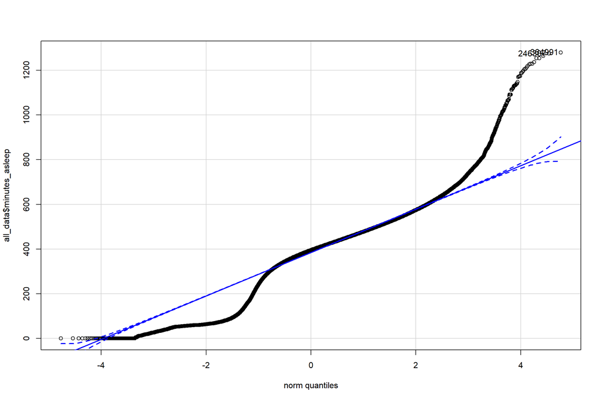

```
## [1] 364991 246307
```

```r
#check normality before modelling to see if anything needs to be transformed.
qqPlot(all_data$minutes_asleep)
```

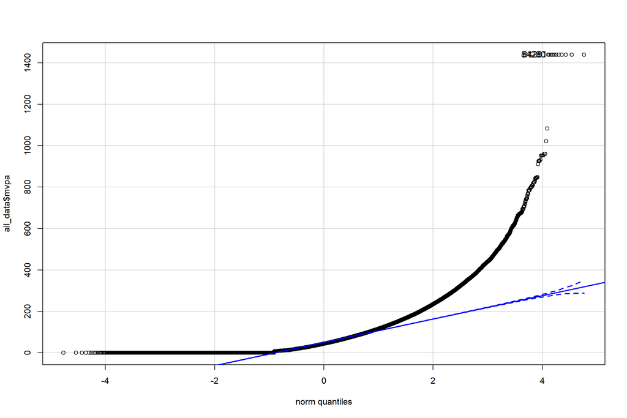

```
## [1] 84280 84281
```

```r
qqPlot(all_data$mvpa)
```

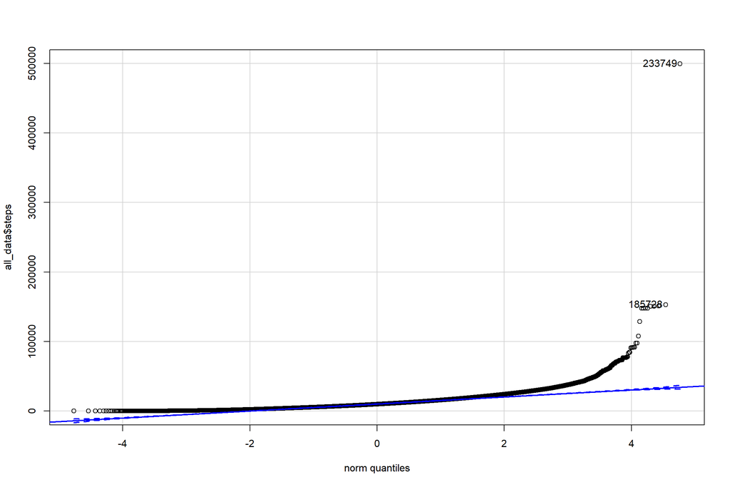

```
## [1] 233749 185728
```

```r
qqPlot(all_data$steps)
```

None of these variables we’ll be modelling are normally distributed. Lets remove the clear outliers for now and we’ll take teh logs after visualisation in order to maintain interpretability.

In order to remove outliers we’ll remove those obs which are >5* or </5 SDs out.

```r
sds<-all_data%>%dplyr::summarise(steps_sd_p=sd(steps)*5, sleep_sd_p=sd(minutes_asleep)*5,
                               mvpa_sd_p=sd(mvpa)*5,
                               sleep_sd_n=sd(minutes_asleep)/5, steps_sd_n=sd(steps)/5,
                               mvpa_sd_n=sd(mvpa)/5)

all_data_cleaned<-all_data%>%
  filter(steps<sds$steps_sd_p & steps>sds$steps_sd_n &
           minutes_asleep < sds$sleep_sd_p & minutes_asleep > sds$sleep_sd_n &
           mvpa < sds$mvpa_sd_p & mvpa > sds$mvpa_sd_n)

rm(all_data) #remove large df
```

We are going to be working with lagged data. This means we need a continuous sequence of days. This means we need to insert missing-filled rows where there are no data.

```r
fill_all_days_fn<-function(x){
  start_date<-min(x$date)
  end_date<-max(x$date)
  x$day_no=as.numeric(difftime(x$date, start_date, units=c('days')))+1
  length_of_data=as.numeric(difftime(end_date, start_date, units=c('days')))
  day_no=as.data.frame(as.numeric(seq(1:length_of_data)))
  colnames(day_no)='day_no'
  day_no<-day_no%>%mutate(ip=x$ip[1], gender=x$gender[1], age=x$age[1], weight=x$weight[1], BMI=x$BMI[1],
                          age_group=x$age_group[1], BMI_group=x$BMI_group[1])
  x<-merge(x, day_no, all=T)
  return(x)
}
all_data_cleaned<-dlply(all_data_cleaned, 'ip', fill_all_days_fn)%>%bind_rows()
```

Now we have sorted and merged the data, let us explore the data We’ll begin with checking the struture and some basic descriptives.

```r
all_data_cleaned$wkday<-as.factor(all_data_cleaned$wkday)
all_data_cleaned$centre<-as.factor(all_data_cleaned$centre)

print(str(all_data_cleaned))
```

```
## 'data.frame':    854763 obs. of  44 variables:
##  $ ip                    : int  149 149 149 149 149 149 149 149 149 149 ...
##  $ age                   : num  23 23 23 23 23 23 23 23 23 23 ...
##  $ gender                : Factor w/ 3 levels "Male","Female",..: 1 1 1 1 1 1 1 1 1 1 ...
##  $ weight                : num  76.5 76.5 76.5 76.5 76.5 76.5 76.5 76.5 76.5 76.5 ...
##  $ BMI                   : num  25.7 25.7 25.7 25.7 25.7 ...
##  $ BMI_group             : Factor w/ 4 levels "Healthy_weight",..: 2 2 2 2 2 2 2 2 2 2 ...
##  $ age_group             : Factor w/ 4 levels "under 30","30 to 45",..: 1 1 1 1 1 1 1 1 1 1 ...
##  $ day_no                : num  1 2 3 4 5 6 7 8 9 10 ...
##  $ date                  : Date, format: "2017-03-21" "2017-03-22" ...
##  $ bin_14_day_of_study   : int  1 1 1 1 1 1 1 1 NA NA ...
##  $ fbday                 : chr  "2017-03-21" "2017-03-22" "2017-03-23" "2017-03-24" ...
##  $ wkday                 : Factor w/ 7 levels "Fri","Mon","Sat",..: 6 7 5 1 3 4 2 6 NA NA ...
##  $ wear_time             : int  1326 1379 1344 1316 1440 1352 1426 1219 NA NA ...
##  $ n_hours               : int  24 24 24 24 24 23 24 23 NA NA ...
```

[output cut: 32 more lines]

Check NAs in each column

```r
colSums(is.na(all_data_cleaned))
```

```
##                     ip                    age                 gender
##                      0                      0                      0
##                 weight                    BMI              BMI_group
##                      0                      0                      0
##              age_group                 day_no                   date
##                      0                      0                 474163
##    bin_14_day_of_study                  fbday                  wkday
##                 478663                 474163                 474163
##              wear_time                n_hours      percent_wear_time
##                 474163                 474163                 474163
##               mins_sed             mins_light            mins_fairly
##                 474163                 474163                 474163
##              mins_very                   mvpa             HRRminsSED
##                 474163                 474163                 474163
##           HRRminsLIGHT             HRRminsMOD             HRRminsVIG
##                 474163                 474163                 474163
##                  steps                   tdee                id_comp
##                 474163                 474163                 474163
##                  index            awake_count         awake_duration
##                 474163                 474163                 474163
##            sleep_start              sleep_end             efficiency
##                 474163                 474163                 474163
##          is_main_sleep         minutes_asleep minutes_to_fall_asleep
##                 474163                 474163                 474163
##   minutes_after_wakeup         restless_count      restless_duration
##                 474163                 474163                 474163
##               study_id       sleep_start_form     onset_rel_midnight
##                 474163                 474163                 474163
##                     ID                 centre
##                 474163                 474163
```

We also have 2 sets of exercise intensity: HRR (heart rate reserve) and the Fitbits own estimates (mins_light etc). We only need one of these so we’ll use the Fitbit estimates for now and drop the other columns. Some other columns can go too (e.g. we have 2 IDs).

```r
dropcols1=c('HRRminsSED', 'HRRminsLIGHT', 'HRRminsMOD', 'HRRminsVIG', 'ID', "minutes_to_fall_asleep", "minutes_after_wakeup", "restless_count",     "restless_duration","study_id")
all_data_cleaned <- all_data_cleaned%>%select(-dropcols1)
head(all_data_cleaned)
```

|  | ip | age | gender | weight | BMI | BMI_group | age_group | day_no | date | bin_14_day_of_study | fbday | wkday | wear_time | n_hours | percent_wear_time | mins_sed | mins_light | mins_fairly | mins_very | mvpa | steps | tdee | id_comp | index | awake_count | awake_duration | sleep_start | sleep_end | efficiency | … |
| --- | --- | --- | --- | --- | --- | --- | --- | --- | --- | --- | --- | --- | --- | --- | --- | --- | --- | --- | --- | --- | --- | --- | --- | --- | --- | --- | --- | --- | --- | --- |
| 1 | 149 | 23 | Male | 76.5 | 25.70888 | Overweight | under 30 | 1 | 2017-03-21 | 1 | 2017-03-21 | Tue | 1326 | 24 | 1.0000000 | 981.4902 | 336.5098 | 48.0000 | 74.0000 | 122.0000 | 17640.17 | 3675.265 | 149 - 2017-03-21 | 0 | 0 | 0 | 2017-03-20 22:10:30 | 2017-03-21 05:36:30 | 94 | … |
| 2 | 149 | 23 | Male | 76.5 | 25.70888 | Overweight | under 30 | 2 | 2017-03-22 | 1 | 2017-03-22 | Wed | 1379 | 24 | 1.0000000 | 934.9565 | 420.0435 | 30.0000 | 55.0000 | 85.0000 | 23694.00 | 3805.578 | 149 - 2017-03-22 | 0 | 0 | 0 | 2017-03-21 21:21:00 | 2017-03-22 05:27:00 | 93 | … |
| 3 | 149 | 23 | Male | 76.5 | 25.70888 | Overweight | under 30 | 3 | 2017-03-23 | 1 | 2017-03-23 | Thu | 1344 | 24 | 1.0000000 | 954.0000 | 356.0000 | 39.0000 | 91.0000 | 130.0000 | 23900.00 | 3868.094 | 149 - 2017-03-23 | 0 | 1 | 3 | 2017-03-22 22:31:00 | 2017-03-23 06:25:00 | 91 | … |
| 4 | 149 | 23 | Male | 76.5 | 25.70888 | Overweight | under 30 | 4 | 2017-03-24 | 1 | 2017-03-24 | Fri | 1316 | 24 | 1.0000000 | 961.5099 | 446.4901 | 7.0000 | 25.0000 | 32.0000 | 16868.54 | 3262.493 | 149 - 2017-03-24 | 0 | 4 | 9 | 2017-03-23 22:33:30 | 2017-03-24 06:30:30 | 90 | … |
| 5 | 149 | 23 | Male | 76.5 | 25.70888 | Overweight | under 30 | 5 | 2017-03-25 | 1 | 2017-03-25 | Sat | 1440 | 24 | 1.0000000 | 878.0000 | 470.0000 | 40.0000 | 52.0000 | 92.0000 | 21737.00 | 3865.143 | 149 - 2017-03-25 | 0 | 1 | 5 | 2017-03-24 22:14:30 | 2017-03-25 06:27:30 | 95 | … |
| 6 | 149 | 23 | Male | 76.5 | 25.70888 | Overweight | under 30 | 6 | 2017-03-26 | 1 | 2017-03-26 | Sun | 1352 | 23 | 0.9583333 | 822.0108 | 323.7284 | 125.2174 | 169.0435 | 294.2609 | 15700.47 | 4873.825 | 149 - 2017-03-26 | 0 | 4 | 8 | 2017-03-25 20:37:00 | 2017-03-26 05:51:00 | 86 | … |

```r
#mean wear time
print(describe(all_data_cleaned))
```

```
## all_data_cleaned
##
##  34  Variables      854763  Observations
## --------------------------------------------------------------------------------
## ip
##        n  missing distinct     Info     Mean      Gmd      .05      .10
##   854763        0     1444        1    962.2    529.8      230      339
##      .25      .50      .75      .90      .95
##      582      946     1319     1626     1711
##
## lowest :  149  150  151  152  153, highest: 1793 1794 1795 1796 1797
## --------------------------------------------------------------------------------
## age
##        n  missing distinct     Info     Mean      Gmd      .05      .10
##   854763        0       60    0.999    45.57    13.47       26       30
##      .25      .50      .75      .90      .95
##       37       45       54       62       65
##
## lowest : 19 20 21 22 23, highest: 74 75 76 80 81
## --------------------------------------------------------------------------------
## gender
##        n  missing distinct
##   854763        0        2
##
## Value        Male Female
## Frequency  245700 609063
## Proportion  0.287  0.713
## --------------------------------------------------------------------------------
## weight
##        n  missing distinct     Info     Mean      Gmd      .05      .10
##   854763        0      582        1    84.52    18.56     61.1     65.7
##      .25      .50      .75      .90      .95
##     72.7     81.8     94.2    108.1    115.5
##
## lowest :  50.5  51.3  51.4  52.1  53.2, highest: 147.8 148.4 150.8 156.9 157.7
## --------------------------------------------------------------------------------
## BMI
##        n  missing distinct     Info     Mean      Gmd      .05      .10
##   854763        0     1431        1    29.63    5.624    23.13    24.09
##      .25      .50      .75      .90      .95
```

[output cut: 246 more lines]

```
## onset_rel_midnight [mins]
##        n  missing distinct
##   380600   474163     3656
##
## lowest : -959 mins -750 mins -664 mins -651 mins -650 mins
## highest: 1374 mins 1374 mins 1375 mins 1376 mins 1378 mins
## --------------------------------------------------------------------------------
## centre
##        n  missing distinct
##   380600   474163        3
##
## Value         CPH    LIS     UL
## Frequency  162709  87830 130061
## Proportion  0.428  0.231  0.342
## --------------------------------------------------------------------------------
```

## PA visualisation

First we’ll do some EDA on the PA data. Steps is generally the most reliable metric of PA so we’ll mainly use this.

Lets start by observing how steps is spread over days of the week

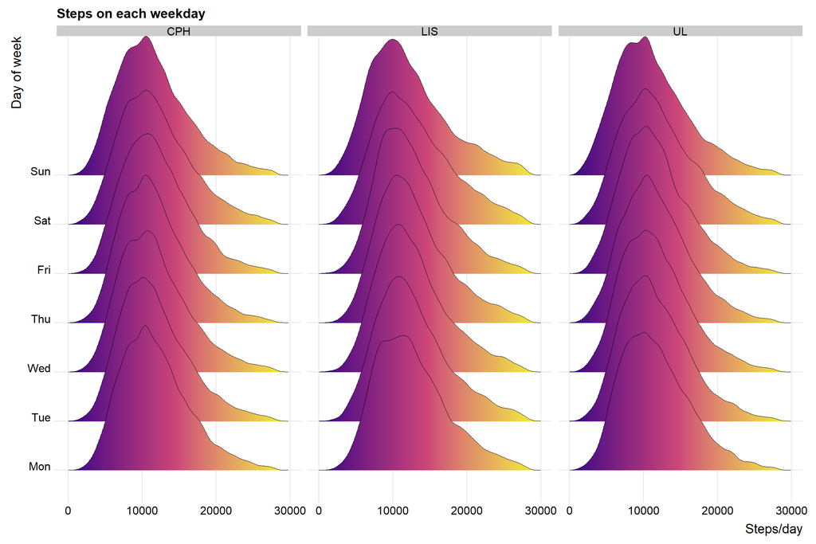

```r
theme_set(theme_ridges())
all_data_cleaned$wkday<-fct_relevel(all_data_cleaned$wkday, "Mon", "Tue", "Wed", "Thu", 'Fri', 'Sat', 'Sun')

ggplot(
  subset(all_data_cleaned, !is.na(centre)),
  aes(x = steps, y = wkday)
  ) +
  geom_density_ridges_gradient(
    aes(fill = ..x..), scale = 3, size = 0.3
    ) +
  scale_fill_gradientn(
    colours = c("#0D0887FF", "#CC4678FF", "#F0F921FF"),
    name = "Steps"
    )+xlim(0,30000)+
  xlab('Steps/day')+ylab('Day of week')+
  labs(title = 'Steps on each weekday')+
  theme(axis.text=element_text(size=12, color='black'))+
  facet_wrap(.~centre)+ theme(legend.position = "none")
```

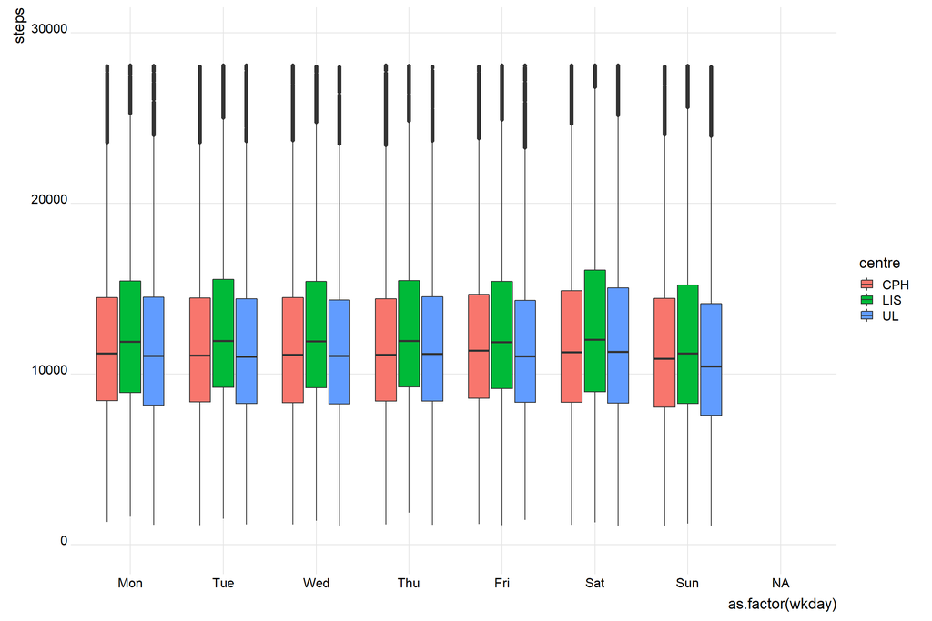

```r
ggplot(all_data_cleaned, aes(x=as.factor(wkday), y=steps, fill=centre))+
  geom_boxplot()+ylim(0,30000)
```

Steps appear to be relatively evenly distributed across days of the week, and this is similar between countries.

Lets consider PA across the year

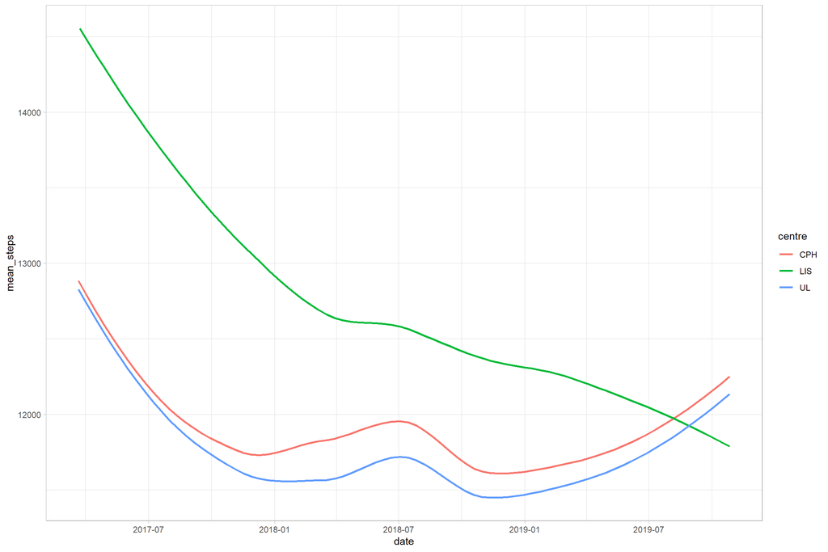

```r
#group data
year_steps_plot<-all_data_cleaned%>%group_by(date, centre)%>%
  dplyr::summarise(mean_steps=mean(steps, na.rm=T))


ggplot(year_steps_plot, aes(x=date, y=mean_steps, color=centre))+
  geom_smooth(method='loess', se=F)+theme_light()
```

Lets generate an MVPA variable by grouping moderate and vigorous PA. This is a commonly used metric in PA research. We’ll then consider associations between activity types by different grouping variables.

Start by looking at these associations by gender

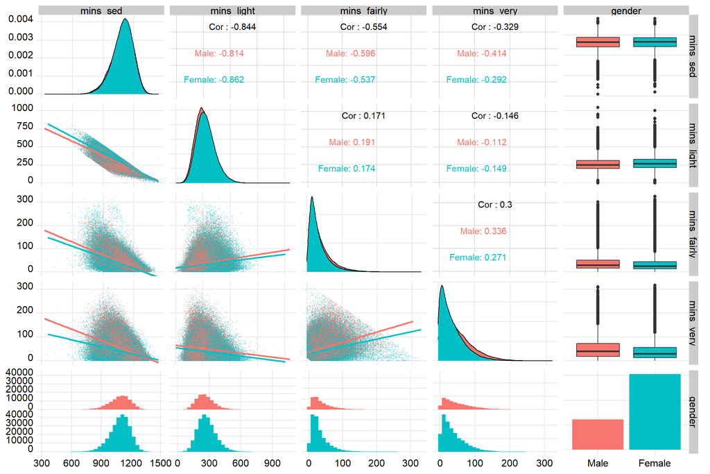

```r
intensity_plot_df<-all_data_cleaned%>%
  mutate(mvpa=mins_fairly + mins_very)%>%
  subset(., select=c(mins_sed, mins_light,
                     mins_fairly, mins_very, mvpa,
                     wkday, gender))

library('GGally')
ggpair_intensity_by_gender<-intensity_plot_df%>%
  dplyr::select(-mvpa, -wkday)%>%
  ggpairs(.,mapping = ggplot2::aes(colour=gender),
          lower = list(continuous = wrap("smooth", alpha = 0.3, size=0.1)))

ggpair_intensity_by_gender
```

One particularly interesting plot we can pull out here is the association between very heavy intensity activity and sedentariness. In particular the gender difference is noteworthy.

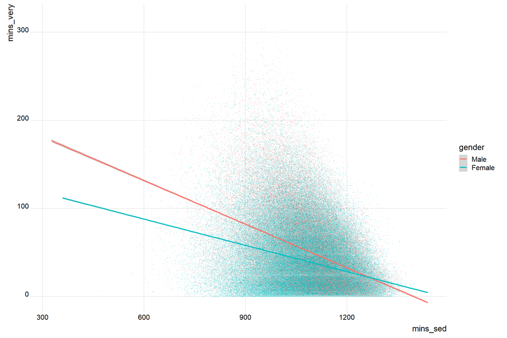

```r
getPlot(ggpair_intensity_by_gender, 4,1) + guides(fill=FALSE)
```

## Sleep visualisation

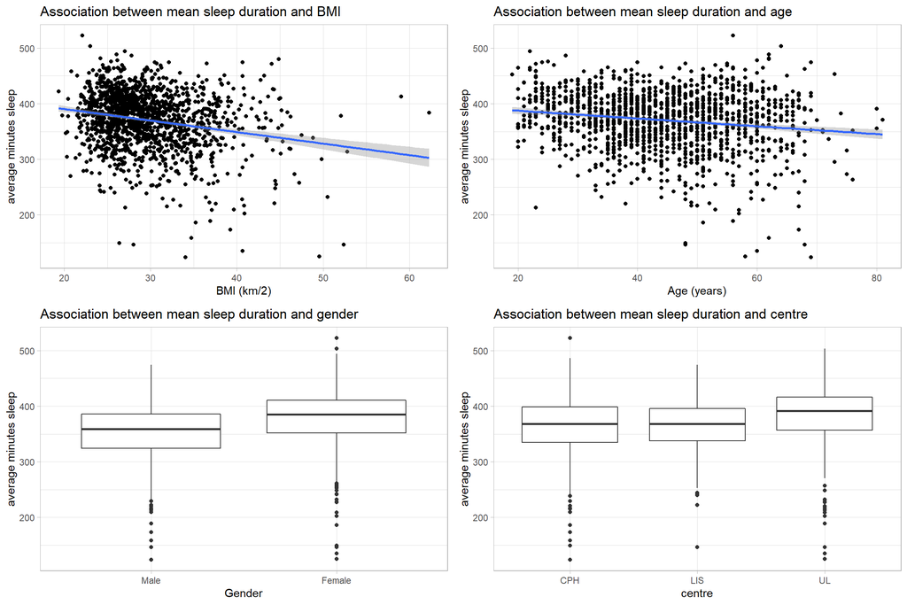

```r
#Aggregate data for 1 row per ppt, keeping characteristic variables
sleep_means<-all_data_cleaned%>%group_by(ip)%>%
  dplyr::summarise(mean_sleep=mean(minutes_asleep, na.rm=T), BMI=BMI[1],
                   gender=gender[1], centre=centre[1],
                   age=age[1])%>%
  reshape2::melt(id.vars=c('ip', 'BMI', 'gender', 'age', 'centre'))

theme_set(theme_light(base_size = 14))
#plot BMI vs sleep
p1<-ggplot(sleep_means,
                     aes(x=BMI,y=value))+geom_point()+
  geom_smooth(method='lm')+
  theme_light()+xlab('BMI (km/2)')+
  ylab('average minutes sleep')+
  ggtitle('Association between mean sleep duration and BMI')+theme_light()

#plot age vs sleep
p2<-ggplot(sleep_means,
                   aes(x=age,y=value))+geom_point()+
  geom_smooth(method='lm')+xlab('Age (years)')+
  ylab('average minutes sleep')+
  ggtitle('Association between mean sleep duration and age')+theme_light()

#plot gender vs sleep
p3<-ggplot(sleep_means,
                      aes(x=gender, y=value))+geom_boxplot()+
  xlab('Gender')+
  ylab('average minutes sleep')+
  ggtitle('Association between mean sleep duration and gender')+theme_light()

#plot centre vs sleep
p4<-ggplot(sleep_means,
                      aes(x=centre, y=value))+geom_boxplot()+
  xlab('centre')+
  ylab('average minutes sleep')+
  ggtitle('Association between mean sleep duration and centre')+theme_light()

grid.arrange(p1, p2, p3, p4, nrow=2, ncol=2)
```

From this we see that average sleep duration decreases with greater age and BMI, females sleep longer than males and some centre differences.

## Associations between sleep and PA

Lets first consider mean associations between average sleep duration and average physical activity. After this we can begin to test the directionality of these effects (if any).

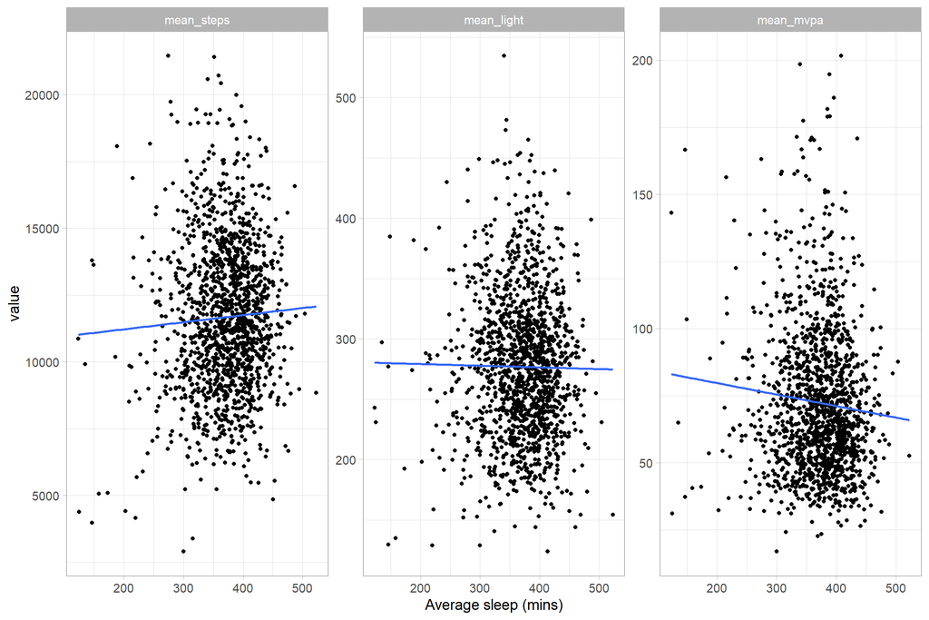

```r
sleep_pa_averages <- all_data_cleaned%>%group_by(ip)%>%
  dplyr::summarise(mean_sleep=mean(minutes_asleep, na.rm=T),
                   mean_steps=mean(steps, na.rm=T), mean_light=mean(mins_light, na.rm=T),
                   mean_mvpa=mean(mvpa, na.rm=T))%>%
  reshape2::melt(id.vars=c('ip', 'mean_sleep'))

ggplot(aes(x=mean_sleep, y=value),
       data=sleep_pa_averages)+geom_point()+
  geom_smooth(method='lm', se=F)+facet_wrap(variable~., scales='free', ncol=3)+
  xlab('Average sleep (mins)')
```

Here we see no clear association between steps and sleep and little with light PA. A negative association can be observed with mvpa, suggesting that as mvpa decreases, sleep increases.

Lets explore this association more closely in different groups

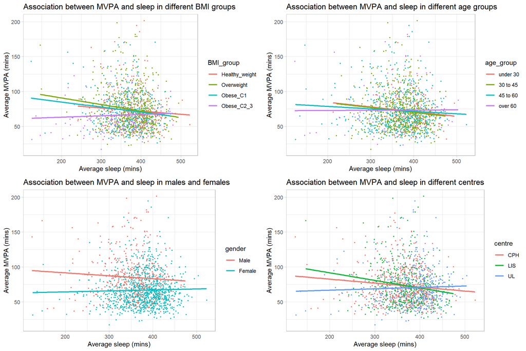

```r
mvpa_sleep_groups<-all_data_cleaned%>%group_by(ip)%>%
  dplyr::summarise(mean_mvpa=mean(mvpa, na.rm=T),
                   mean_sleep=mean(minutes_asleep, na.rm=T), age_group=age_group[1],
                   BMI_group=BMI_group[1], gender=gender[1],
                   centre=centre[1])

#plot MVPA vs sleep in different age groups
p1<-ggplot(mvpa_sleep_groups,
                     aes(x=mean_sleep,y=mean_mvpa,
                         col=BMI_group))+geom_point(size=0.5)+
  geom_smooth(method='lm', se=F)+
  theme_light()+xlab('Average sleep (mins)')+
  ylab('Average MVPA (mins)')+
  ggtitle('Association between MVPA and sleep in different BMI groups')

#plot MVPA vs sleep in different age groups
p2<-ggplot(mvpa_sleep_groups,
                     aes(x=mean_sleep,y=mean_mvpa,
                         col=age_group))+geom_point(size=0.5)+
  geom_smooth(method='lm', se=F)+
  theme_light()+xlab('Average sleep (mins)')+
  ylab('Average MVPA (mins)')+
  ggtitle('Association between MVPA and sleep in different age groups')

#plot MVPA vs sleep in different genders
p3<-ggplot(mvpa_sleep_groups,
                     aes(x=mean_sleep,y=mean_mvpa,
                         col=gender))+geom_point(size=0.5)+
  geom_smooth(method='lm', se=F)+
  theme_light()+xlab('Average sleep (mins)')+
  ylab('Average MVPA (mins)')+
  ggtitle('Association between MVPA and sleep in males and females')

#plot MVPA vs sleep in different centres
p4<-ggplot(mvpa_sleep_groups,
                     aes(x=mean_sleep,y=mean_mvpa,
                         col=centre))+geom_point(size=0.5)+
  geom_smooth(method='lm', se=F)+
  theme_light()+xlab('Average sleep (mins)')+
  ylab('Average MVPA (mins)')+
  ggtitle('Association between MVPA and sleep in different centres')

grid.arrange(p1, p2, p3, p4, nrow=2, ncol=2)
```

This leaves the question: does more sleep result in less MVPA? Or does more MVPA result in less sleep? Or is the relationship bidirectional?

First, lets log transform the data and again check the distribution

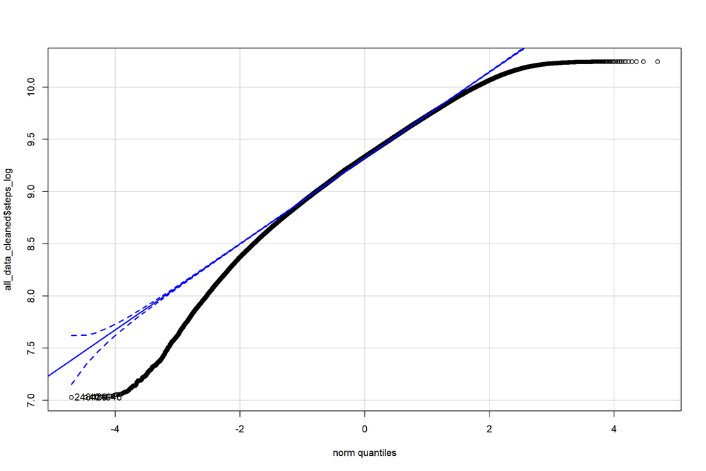

```
## [1] 248489 401046
```

```r
all_data_cleaned$steps_log <- log(all_data_cleaned$steps)
all_data_cleaned$mvpa_log <- log(all_data_cleaned$mvpa)
all_data_cleaned$mins_sleep_log <- log(all_data_cleaned$minutes_asleep)

#check normality before modelling to see if anything needs to be transformed.
qqPlot(all_data_cleaned$steps_log)
```

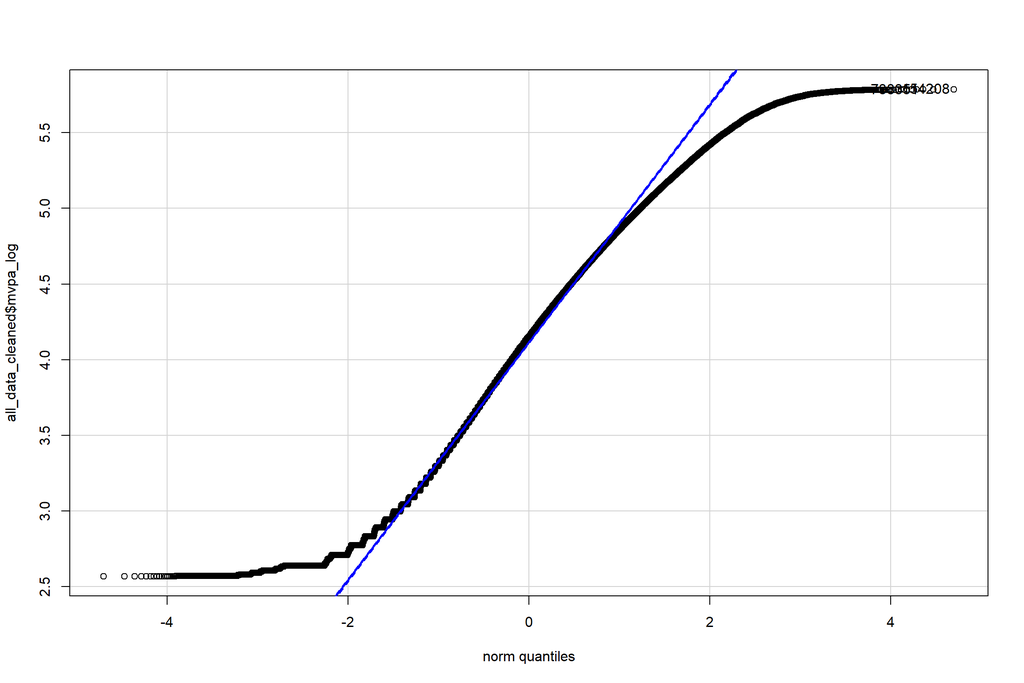

```
## [1] 154208 738351
```

```r
qqPlot(all_data_cleaned$mvpa_log)
```

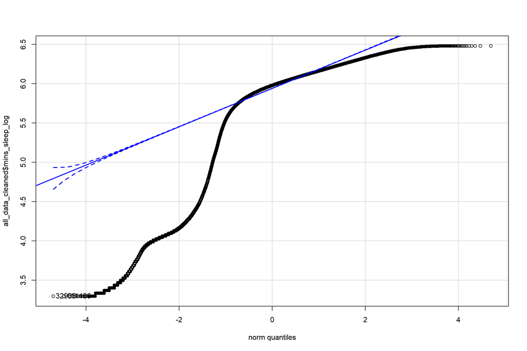

```
## [1]  32936 111480
```

```r
qqPlot(all_data_cleaned$mins_sleep_log)
```

It is clear that these data are not parametric and as such we should be careful not to use parametric statistics. We’ll continue to test whether more sleep results in less MVPA; or whether more MVPA results in less sleep (or both) using non-parametric statistics

```r
#function to calculate individual level correlations (Spearman)
within_subject_cor_fn<-function(x){
  same_day_cor<-cor(na.omit(x$mvpa_log), na.omit(x$mins_sleep_log), method='spearman')
  x$lag_sleep<-lag(x$mins_sleep_log)
  x<-x[-1,]
  lagged_cor<-cor(na.omit(x$mvpa_log), na.omit(x$lag_sleep), method='spearman')
  cors<-data.frame(cbind(same_day_cor, lagged_cor))
  colnames(cors)<-c('same_day', 'lagged_sleep')
  cors$ip<-x$ip[1]
  return(cors)
}

individual_mvpa_sleep_cor<-dlply(all_data_cleaned, 'ip', within_subject_cor_fn)%>%
  bind_rows()

print(head(arrange(individual_mvpa_sleep_cor, same_day)),10)
```

```
##     same_day lagged_sleep   ip
## 1 -0.6474954  -0.18638113 1729
## 2 -0.5833333  -0.11904762  405
## 3 -0.5466613  -0.39960273 1096
## 4 -0.5225437   0.05797710  838
## 5 -0.5043654   0.09474263  508
## 6 -0.4557509  -0.17313484 1596
```

```r
print(head(arrange(individual_mvpa_sleep_cor, lagged_sleep)),10)
```

```
##      same_day lagged_sleep   ip
## 1  0.71428571   -0.7142857 1655
## 2 -0.30429154   -0.6219887  683
## 3  0.35462555   -0.5495868  279
## 4  0.04308202   -0.4767037  682
## 5 -0.10000000   -0.4761905  268
## 6  0.05797710   -0.4616903  548
```

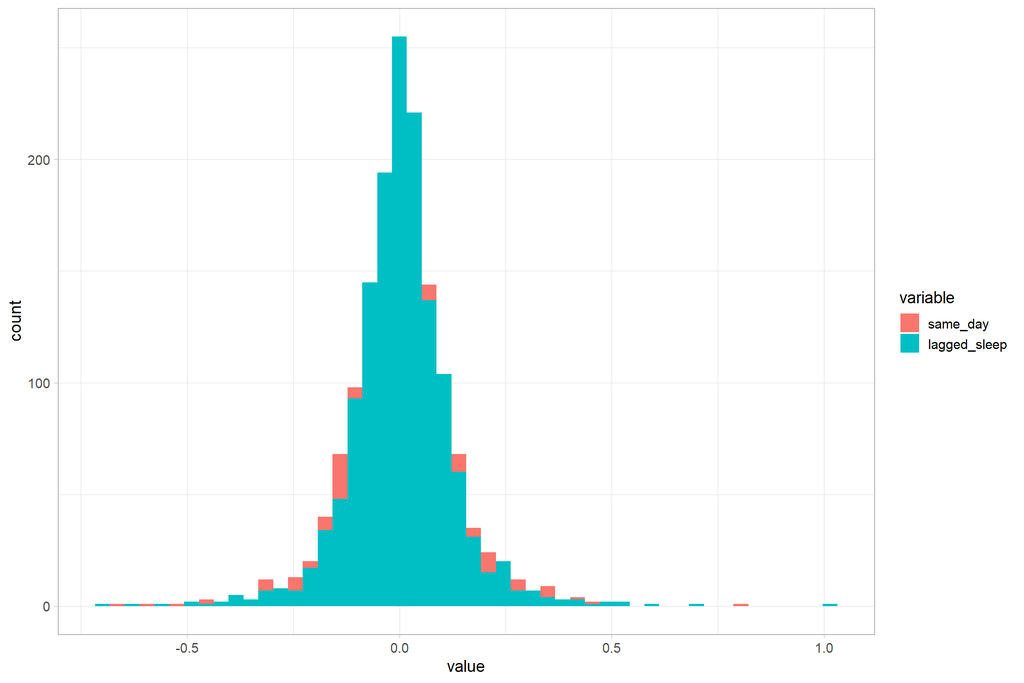

```r
individual_mvpa_sleep_cor_long<-reshape2::melt(individual_mvpa_sleep_cor,
                                               id.var='ip')

ggplot(individual_mvpa_sleep_cor_long, aes(x=value, fill=variable))+
  geom_histogram(position = "identity", bins=50)
```

No clear tendency in either direction.

```r
#scale variables first. This helps convergence in LMMs:
all_data_cleaned$ip<-as.factor(all_data_cleaned$ip)
all_data_cleaned<-transform(all_data_cleaned,
    mins_sleep_scaled=scale(mins_sleep_log),
    mvpa_scaled=scale(mvpa_log),
    steps_scaled=scale(steps_log))
```

```r
#run mixed effect model with random effect for each individual
# the below model asks:
# does the amount of exercise done on a day affect sleep that same night?
modelling_df=all_data_cleaned%>%mutate(lag_log_sleep=lag(mins_sleep_scaled))%>%
                                         filter(!is.na(mvpa_scaled) & !is.na(mins_sleep_scaled) &
                                                  !is.na(lag_log_sleep))

mvpa_model<-gam(mins_sleep_scaled ~ mvpa_scaled, data=modelling_df)
print(summary(mvpa_model))
```

```
##
## Family: gaussian
## Link function: identity
##
## Formula:
## mins_sleep_scaled ~ mvpa_scaled
##
## Parametric coefficients:
##              Estimate Std. Error t value             Pr(>|t|)
## (Intercept) -0.081381   0.002078 -39.164 < 0.0000000000000002 ***
## mvpa_scaled  0.007954   0.002103   3.783             0.000155 ***
## ---
## Signif. codes:  0 '***' 0.001 '**' 0.01 '*' 0.05 '.' 0.1 ' ' 1
##
##
## R-sq.(adj) =  5.11e-05   Deviance explained = 0.00549%
## GCV = 1.1209  Scale est. = 1.1209    n = 260542
```

The significant effect with a positive estimate suggests that more MVPA is associated with more sleep that night. However, this only explains <0.01% of the variance suggesting that while significant the association is not valuable.

We can reverse this to test directionality by testing lagg sleep i.e.

```r
# the below model asks:
# does the amount of sleep achieved in the previous night influence subsequent MVPA?
lagged_sleep_model<-gam(mvpa ~ lag_log_sleep, data=modelling_df)
print(summary(lagged_sleep_model))
```

```
##
## Family: gaussian
## Link function: identity
##
## Formula:
## mvpa ~ lag_log_sleep
##
## Parametric coefficients:
##               Estimate Std. Error t value            Pr(>|t|)
## (Intercept)    80.2723     0.1077 745.087 <0.0000000000000002 ***
## lag_log_sleep  -0.1820     0.1021  -1.782              0.0747 .
## ---
## Signif. codes:  0 '***' 0.001 '**' 0.01 '*' 0.05 '.' 0.1 ' ' 1
##
##
## R-sq.(adj) =  8.35e-06   Deviance explained = 0.00122%
## GCV = 3021.1  Scale est. = 3021      n = 260542
```

Here we see that the previous nights sleep is not a significant (p>0.05) predictor of subsequent MVPA. This is evidence in favour of only one direction, however the effects are weak therefore, at group level, we may suggest that MVPA and sleep are not associated in either direction.

Lets consider using steps instead of MVPA:

```r
#steps predicting sleep that night
steps_model<-gam(mins_sleep_scaled ~ steps_scaled, data=modelling_df)
print(summary(steps_model))
```

```
##
## Family: gaussian
## Link function: identity
##
## Formula:
## mins_sleep_scaled ~ steps_scaled
##
## Parametric coefficients:
##               Estimate Std. Error t value            Pr(>|t|)
## (Intercept)  -0.082179   0.002075  -39.60 <0.0000000000000002 ***
## steps_scaled  0.029839   0.002105   14.18 <0.0000000000000002 ***
## ---
## Signif. codes:  0 '***' 0.001 '**' 0.01 '*' 0.05 '.' 0.1 ' ' 1
##
##
## R-sq.(adj) =  0.000767   Deviance explained = 0.0771%
## GCV = 1.1201  Scale est. = 1.1201    n = 260542
```

Again, this is highly significant at group level but explains <0.1% so is not valuable.

```r
#prior nights sleep predicting subsequent steps
lagged_sleep_model_steps<-gam(steps_scaled ~ lag_log_sleep, data=modelling_df)
print(summary(lagged_sleep_model_steps))
```

```
##
## Family: gaussian
## Link function: identity
##
## Formula:
## steps_scaled ~ lag_log_sleep
##
## Parametric coefficients:
##               Estimate Std. Error t value            Pr(>|t|)
## (Intercept)   0.043971   0.001930   22.79 <0.0000000000000002 ***
## lag_log_sleep 0.037613   0.001829   20.57 <0.0000000000000002 ***
## ---
## Signif. codes:  0 '***' 0.001 '**' 0.01 '*' 0.05 '.' 0.1 ' ' 1
##
##
## R-sq.(adj) =  0.00162   Deviance explained = 0.162%
## GCV = 0.96903  Scale est. = 0.96902   n = 260542
```

Here we observe a bidirectional relationship between sleep and steps. The strongest observed effect was that prior nights sleep is positively associated with steps the next day. However, these are linear models and it is very possible we are observing non-linear relationships AND importantly, we know the data is non-parametric, however we are previously looking at parametric coefficients. To examine this further, lets add cubic regression splines to the model.

```r
#prior nights sleep predicting subsequent steps
lagged_sleep_model_steps_cub<-gam(steps_scaled ~ s(lag_log_sleep, bs='cp'), data=modelling_df)
print(summary(lagged_sleep_model_steps_cub))
```

```
##
## Family: gaussian
## Link function: identity
##
## Formula:
## steps_scaled ~ s(lag_log_sleep, bs = "cp")
##
## Parametric coefficients:
##             Estimate Std. Error t value            Pr(>|t|)
## (Intercept) 0.042711   0.001924    22.2 <0.0000000000000002 ***
## ---
## Signif. codes:  0 '***' 0.001 '**' 0.01 '*' 0.05 '.' 0.1 ' ' 1
##
## Approximate significance of smooth terms:
##                   edf Ref.df     F             p-value
## s(lag_log_sleep) 8.06      9 184.4 <0.0000000000000002 ***
## ---
## Signif. codes:  0 '***' 0.001 '**' 0.01 '*' 0.05 '.' 0.1 ' ' 1
##
## R-sq.(adj) =  0.00632   Deviance explained = 0.635%
## GCV = 0.96449  Scale est. = 0.96446   n = 260542
```

We now explain >0.6% of the variance, ~4 fold increase, however it is still not substantial. We can visualise this:

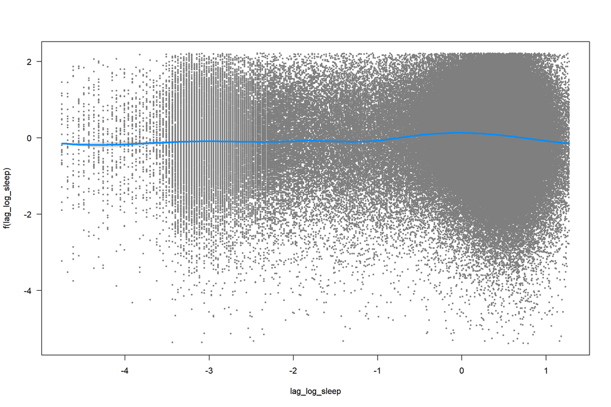

```r
visreg(lagged_sleep_model_steps_cub)
```

But given the weak relationship there are no clear trends to observe.

NEXT STEPS: break the sample down into ‘responders/non-responders’ for each direction, based on extracting IDs from the correlation list… Then we can examine the gam (s()) R^2 in specific groups and see if its more meaningful.

```r
PA_inc_sleep_ids = individual_mvpa_sleep_cor%>%arrange(desc(same_day))%>%head(100)%>%dplyr::select(ip)
sleep_inc_PA_ids = individual_mvpa_sleep_cor%>%arrange(desc(lagged_sleep))%>%head(100)%>%dplyr::select(ip)

PA_inc_sleep = subset(modelling_df, ip %in% PA_inc_sleep_ids$ip)
sleep_inc_PA = subset(modelling_df, ip %in% sleep_inc_PA_ids$ip)
```

Now we have 2 DFs where we know that (a) prior sleep is associated with subsequent PA and (b) PA is associated with subsequent sleep. Lets run the most effective models in these groups again to see how much variance we can explain with these

```r
lagged_sleep_model_steps_cub<-gam(steps_scaled ~ s(lag_log_sleep, bs='cp'), data=sleep_inc_PA)
print(summary(lagged_sleep_model_steps_cub))
```

```
##
## Family: gaussian
## Link function: identity
##
## Formula:
## steps_scaled ~ s(lag_log_sleep, bs = "cp")
##
## Parametric coefficients:
##             Estimate Std. Error t value         Pr(>|t|)
## (Intercept)  0.09265    0.01334   6.943 0.00000000000426 ***
## ---
## Signif. codes:  0 '***' 0.001 '**' 0.01 '*' 0.05 '.' 0.1 ' ' 1
##
## Approximate significance of smooth terms:
##                    edf Ref.df     F          p-value
## s(lag_log_sleep) 6.731      9 6.871 0.00000000000552 ***
## ---
## Signif. codes:  0 '***' 0.001 '**' 0.01 '*' 0.05 '.' 0.1 ' ' 1
##
## R-sq.(adj) =  0.0103   Deviance explained = 1.15%
## GCV = 1.0109  Scale est. = 1.0095    n = 5670
```

The variance explained is still very low

```r
#steps predicting sleep that night
steps_model<-gam(mins_sleep_scaled ~ s(steps_scaled, bs='cp'), data=PA_inc_sleep)
print(summary(steps_model))
```

```
##
## Family: gaussian
## Link function: identity
##
## Formula:
## mins_sleep_scaled ~ s(steps_scaled, bs = "cp")
##
## Parametric coefficients:
##             Estimate Std. Error t value            Pr(>|t|)
## (Intercept)  0.11842    0.01126   10.52 <0.0000000000000002 ***
## ---
## Signif. codes:  0 '***' 0.001 '**' 0.01 '*' 0.05 '.' 0.1 ' ' 1
##
## Approximate significance of smooth terms:
##                   edf Ref.df     F     p-value
## s(steps_scaled) 8.873      9 5.519 0.000000101 ***
## ---
## Signif. codes:  0 '***' 0.001 '**' 0.01 '*' 0.05 '.' 0.1 ' ' 1
##
## R-sq.(adj) =  0.00706   Deviance explained = 0.856%
## GCV = 0.7462  Scale est. = 0.74495   n = 5876
```

Again these, while highly significant, are not substantial models.